# The geometric interpretation of the covariance matrix

## Covariance matrices

A multivariate dataset will typically be a matrix whose rows are observations and whose columns are features of those observations (or the other way around, but we will stick to the former convention here). The variables may have different variances, and they may covary to a smaller or larger degree. All that information is contained in the covariance matrix.

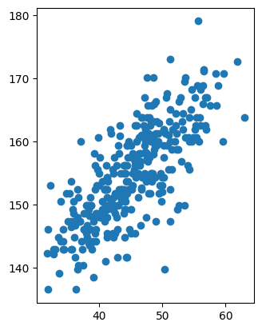

```python
import pandas as pd
import matplotlib.pyplot as plt

# read the data
data = pd.read_csv("HeightWeight.csv", sep=";")
# remove the kids as the weight-height correlation is different there
data = data.loc[data["age"] > 20]
# drop irrelevant columns
data = data.drop(columns=["age", "male"])
# tranpose the matrix to the format used in maths books
data = data.transpose()

#plt.ylim(140, 180)
#plt.xlim(25, 65)
plt.scatter(data.loc[["weight"],:], data.loc[["height"],:])
plt.gca().set_aspect('equal', adjustable='box')
```

We see a clear covariance between height and weight. The mathematical definition of covariance between two variables $x$ and $y$ is

$$\frac{1}{n-1}\displaystyle\sum_1^{n} (x_n - \bar{x})(y_n - \bar{y}) $$

where $\bar{x}$ and $\bar{y}$ are the means of vectors $x$ and $y$. So if both $x_n$ and $y_n$ are above or below their mean, the product is positive. Similarly, the *variance* of vector $x$ is just its covariance with itself:

$$\frac{1}{n-1}\displaystyle\sum_1^{n} (x_n - \bar{x})^2$$

Since we subtract the mean when computing the covariance, it is useful to *center* our data by substracting the mean from each observation.

```
             0          1          2         3         4          5    \
height -2.982724 -15.047724 -18.222724  2.097276 -9.332724   9.082276
weight  2.677324  -8.662476 -13.283444  7.893632 -3.871410  17.844307

             6          7          9         10   ...       524       528  \
height -5.522724  14.162276  10.352276 -0.442724  ...  1.462276  5.907276
weight -6.904807  10.331689   9.339457  4.746838  ... -1.121509  2.734023

             529       532       533       534        537       540       541  \
height -8.697724  1.462276 -2.347724  7.812276 -11.872724  7.812276  1.462276
weight -5.742477 -4.098206 -4.325002  1.883538 -10.902086  7.014798  8.914214

             543
height  4.002276
weight  7.383341

[2 rows x 331 columns]
```

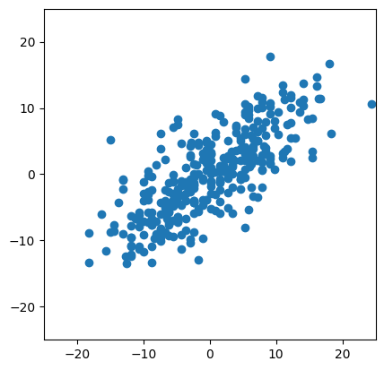

```python
centered_data = data.sub(data.mean(axis=1), axis=0)

plt.ylim(-25, 25)
plt.xlim(-25, 25)
plt.scatter(centered_data.loc[["height"],:], centered_data.loc[["weight"],:])
plt.gca().set_aspect('equal', adjustable='box')

print(centered_data)
```

We observe the same correlation here. And now, since we have centered the data, the covariance between observation vectors $x$ and $y$ is just the dot product $x \cdot y$ and the variance of $x$ is just $x \cdot x$. And to get the covariance matrix, i.e. the dot products of each row with all the other rows, we just multiply the transpose of our data matrix with itself

$$\frac{1}{n-1}DD^T$$

```python
print((1/(len(centered_data.columns) -1)) * (centered_data @ centered_data.T))
```

```
           height     weight
height  60.829745  38.068214
weight  38.068214  41.536065
```

There is also a built-in function in pandas, though it wants the matrix in the opposite form (observations are rows). It gives the same result.

```python
# get the covariance matrix

cov = centered_data.transpose().cov()
print(cov)
```

```
           height     weight
height  60.829745  38.068214
weight  38.068214  41.536065
```

Also note (as is kind of obvious from the definition) that centering did not affect the (co-)variances.

```python
data.transpose().cov()
```

|  | height | weight |
| --- | --- | --- |
| height | 60.829745 | 38.068214 |
| weight | 38.068214 | 41.536065 |

## Geometric interpretation of the covariance matrix

The covariance matrix of a dataset is a linear transformation that transforms white data (i.e. random, normal distributed data) into the observed data!

Let us look at some white data

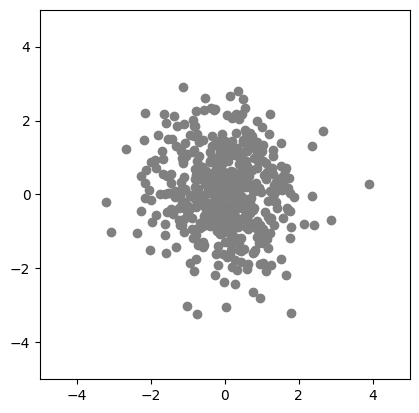

```python
# first plot some random data

import numpy as np
import matplotlib.pyplot as plt
import pandas as pd

n_data = ([], [])

for i in range (1,500):
    data = np.random.normal(size=2)
    n_data[0].append(data[0])
    n_data[1].append(data[1])

normal_data = pd.DataFrame({'x':n_data[0], 'y':n_data[1]})


plt.scatter(normal_data["x"], normal_data["y"], c='grey')

plt.ylim(-5, 5)
plt.xlim(-5, 5)
plt.gca().set_aspect('equal', adjustable='box')

plt.show()
```

Let us first look at the covariance matrix of the white data.

```python
print(normal_data.cov())
```

```
          x         y
x  0.935047 -0.082724
y -0.082724  1.140783
```

The actual covariance matrix of the random normal data will deviate a little from the theoretical covariance matrix, which is just the identity matrix:

$$D_nD_n^T = I$$

Now we want to find the linear transformation $T$ that transforms white data $D_n$ into the observed data $D$. $T$ can be decomposed into a rotation matrix $R$ and a diagonal scaling matrix $M$.

$$D = TD_n = RMD_n$$

Now the covariance matrix of the observed data is $DD^T$.

$$ S = DD^T = (RMD_n)(RMD_n)^T = (RMD_n)((RM)(D_n))^T = (RMD_n)D_n^T(RM)^T = (RM)(D_nD_n^T)(RM)^T = (RM)(RM)^T = RMM^TR^T = RMMR^T $$

because $M$ is a diagonal matrix identical to its own transpose. So if we can decompose the covariance matrix into matrices $R$ and $M$ such that $S = RMMR^T$, we have the linear transformation $T = RM$ that turns white data into the observed data. And it turns out that the eigenvalue decomposition of $S = V\Lambda V^{-1} = V\Lambda^{\frac{1}{2}}\Lambda^{\frac{1}{2}}V^{-1}$ gives us exactly that, where $\Lambda$ is a matrix with the eigenvalues of $S$ on its diagonal and $V$ has the corresponding eigenvectors in the same order. (See the notebook on MDS for more on the eigenvalue decomposition.)

```
[[-0.78919099  0.61414785]
 [-0.61414785 -0.78919099]]
[[9.51075187 0.        ]
 [0.         3.45129085]]
```

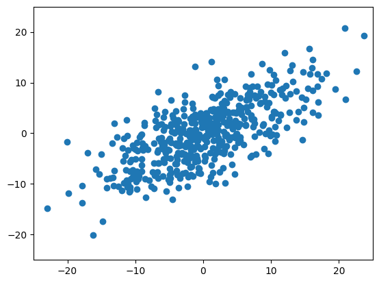

```python
import math

# get the covariance matrix
cov = centered_data.T.cov()

# now take the eigenvalues of the covariance matrix
# and sort them ascending
eigenvalues, V = np.linalg.eigh(cov)
ind = np.argsort(eigenvalues)[::-1]
eigenvalues = eigenvalues[ind]
V = V[:, ind]
L = np.diag(np.sqrt(eigenvalues))
print(V)
print(L)

# Now generate data by applying VL to the normal data
generated_data = ((V @ L @ normal_data.T).T)

# and plot the results
plt.ylim(-25, 25)
plt.xlim(-25, 25)
plt.scatter(generated_data[0], generated_data[1])
```

## Eigendecomposition of the covariance matrix

Lets look at the covariance matrix in another way. The *scalar projection* $a_b$ of a vector $a$ onto a vector $b$ is given by

$$a_b = a \cdot \frac{b}{||b||} $$

i.e. the dot product of $a$ and the unit vector in the direction of $b$. Now if our data are columns of $D$ we can project them all onto some vector unit vector $a$ with

$$a^TM$$

For example, we can project our centered data onto $ a_1 = (0, 1)^T$, which will give us only the weight axis, or onto $a_2 = (\frac{1}{\sqrt{2}}, \frac{1}{\sqrt{2}})^T$, which will give us an axis that "pays equal attention" to height and weight.

```python
a1 = np.matrix([[0],
               [1]])
a2 = np.matrix([[math.sqrt(0.5)],
                [math.sqrt(0.5)]])
print(centered_data)
print(a1.T @ centered_data)
print(a2.T @ centered_data)
```

```
             0          1          2         3         4          5    \
height -2.982724 -15.047724 -18.222724  2.097276 -9.332724   9.082276
weight  2.677324  -8.662476 -13.283444  7.893632 -3.871410  17.844307

             6          7          9         10   ...       524       528  \
height -5.522724  14.162276  10.352276 -0.442724  ...  1.462276  5.907276
weight -6.904807  10.331689   9.339457  4.746838  ... -1.121509  2.734023

             529       532       533       534        537       540       541  \
height -8.697724  1.462276 -2.347724  7.812276 -11.872724  7.812276  1.462276
weight -5.742477 -4.098206 -4.325002  1.883538 -10.902086  7.014798  8.914214

             543
height  4.002276
weight  7.383341

[2 rows x 331 columns]
        0         1          2         3        4          5         6    \
0  2.677324 -8.662476 -13.283444  7.893632 -3.87141  17.844307 -6.904807

         7         9         10   ...       524       528       529       532  \
0  10.331689  9.339457  4.746838  ... -1.121509  2.734023 -5.742477 -4.098206

        533       534        537       540       541       543
0 -4.325002  1.883538 -10.902086  7.014798  8.914214  7.383341

[1 rows x 331 columns]
       0          1          2         3         4         5         6    \
0 -0.21595 -16.765643 -22.278225  7.064639 -9.336733  19.03997 -8.787591

         7          9         10   ...       524       528        529  \
0  17.319849  13.924158  3.043468  ...  0.240959  6.110322 -10.210764

        532      533       534        537        540       541       543
0 -1.863884 -4.71833  6.855976 -16.104223  10.484325  7.337287  8.050847

[1 rows x 331 columns]
```

Now the question we ask ourselves is: how can we choose the vector $a$ so as to maximize the variance of the projected data $v^TD$. Recall that the variance of the projected data is given by

$$(v^TD)(v^TD)^T = (v^TD)(D^Tv) = v^T(DD^T)v = v^TSv$$

## Principal Component Analysis

The goal of PCA is to find an orthogonal $P$ that determines a change of variable such that $X = PY$ (and $Y = P^TX$) with the property that the new variables are uncorrelated. $P$ has dimensions $p\times p$, where $p$ is the number of observations in in column in $X$.

The covariance matrix of the data expressed with new variables $Y$ is $P^TSP$, where $S = \frac{1}{n-1}XX^T$ is the covariance matrix of $X$:

$$\frac{1}{n-1}YY^T = \frac{1}{n-1}(P^TX)(P^TX)^T = \frac{1}{n-1}(P^TX)(X^TP) = P^T\frac{1}{n-1}(XX^T)P = P^TSP$$

This means we want to find a matrix $P$ such that $P^TSP$ is diagonal (all non-diagonal entries are 0, so there is no covariance). The eigenvalue decomposition of $S$ gives us exactly that, because it gives us $S = PDP^T$ (where $D$ is diagonal); if follows that $P^TSP = D$.

```python
# (Notice that the pandas matrix is transposed compared to the standard in mathematics,
# so we transpose the matrix before using pandas' cov() function.

cov = centered_data.T.cov()
print(cov)

# now take the eigenvalues of the covariance matrix
# since the order of eigenvalues returned by eigh is not dependable, we sort them using np.argsort
eigenvalues, P = np.linalg.eigh(cov)
ind = np.argsort(eigenvalues)[::-1]
eigenvalues = eigenvalues[ind]
P = P[:, ind]

D = np.diag(eigenvalues)

print(P)
print(D)
```

```
           height     weight
height  60.829745  38.068214
weight  38.068214  41.536065
[[-0.78919099  0.61414785]
 [-0.61414785 -0.78919099]]
[[90.45440123  0.        ]
 [ 0.         11.91140856]]
```

Now we know from above that by projecting the data onto the eigenvector that correponds to the largest eigenvalue of the covariance matrix, we maximize the variance of the projected data. In this way, we can use PCA to discard dimensions of the data that contain less variance and thereby reduce the dimensionality of the data while preserving most of the variance. In this case, we can see that the first dimension contains $\frac{90.45}{(90.45+11.91)} = 88.4\%$ of the variance.

```python
90.45/(90.45+11.91)
```

```
0.8836459554513482
```

Now we can plot our data with the eigenvectors added, to visualize how they capture the directions of variance in the dataset. To show the difference in magnitude, we scale the vectors by the (square root) of the eigenvalue.

```
-0.7891909872522258
0.6141478532404531
```

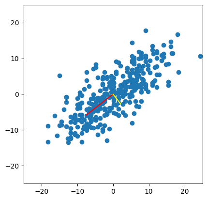

```python
print(P[0,0])
print(P[0,1])

plt.ylim(-25, 25)
plt.xlim(-25, 25)
plt.scatter(centered_data.loc[["height"],:], centered_data.loc[["weight"],:])
plt.plot([0, (P[0,0] * math.sqrt(eigenvalues[0]))], [0, (P[1,0] * math.sqrt(eigenvalues[0]))], color="red")
plt.plot([0, (P[0,1] * math.sqrt(eigenvalues[1]))], [0, (P[1,1] * math.sqrt(eigenvalues[1]))], color="yellow")
plt.gca().set_aspect('equal', adjustable='box')
```